# 数据读入与合并

```python
import pandas as pd

file_path0 = "/Users/churchillfelix/Desktop/data/0.csv"
file_path1 = "/Users/churchillfelix/Desktop/data/1.csv"
file_path2 = "/Users/churchillfelix/Desktop/data/2.csv"

df0 = pd.read_csv(file_path0)
df0['date']=1
df1 = pd.read_csv(file_path1)
df1['date']=2
df2 = pd.read_csv(file_path2)
df2['date']=3

df = pd.concat([df0, df1, df2], ignore_index=True)
```

# 问题一

计算三个交易日中该股票的最高价、最低价、3日累计涨幅、3 日累计成交金额、3日平均振幅、3 日平均盘口变化次数(当前 tick 的apl或bpl 和上个tick 不一样），结果需要打印出来

```python
# 最高价、最低价、累计涨幅、累计成交金额
max_price = df['high'].max()
min_price = df['low'].min()
total_increase = df['preclose'].iloc[-1] / df['preclose'].iloc[0] - 1#应该使用收盘价
total_turnover = df['ttval'].sum()

# 计算3日平均振幅
grouped_data = df.groupby('date')
daily_amplitude = grouped_data.apply(lambda x: x['high'].max() - x['low'].min())
average_amplitude = daily_amplitude.mean()


# 计算3日平均盘口变化次数
df['ap1_change'] = df['ap1'] != df['ap1'].shift(1)
df['bp1_change'] = df['bp1'] != df['bp1'].shift(1)
df['total_change'] = df['ap1_change'] | df['bp1_change']
total_changes = df['total_change'].sum()
average_change = total_changes/3

print("最高价：{:.2f}".format(max_price))
print("最低价：{:.2f}".format(min_price))
print("3日累计涨幅：{:.2f}%".format(total_increase * 100))
print("3日累计成交金额：{:.2f}".format(total_turnover))
print("3日平均振幅：{:.2f}".format(average_amplitude))
print("3日平均盘口变化次数：{:.2f}".format(average_change))
```

```
最高价：26.96
最低价：23.89
3日累计涨幅：11.03%
3日累计成交金额：12530971896372.68
3日平均振幅：1.57
3日平均盘口变化次数：2598.67
```

# 问题二

观察该股票日内相邻 tick 间成交金额的变化，分析可能的原因

```python
def calculate_changes(group):
    group['amount_change'] = group['ttval'].diff()
    group['volume_change'] = group['ttvol'].diff()
    return group

# 对每个日期分组并计算金额变化和成交量变化
df = df.groupby('date').apply(calculate_changes)
```

```python
threshold = 10000000  # 设置一个阈值，可以根据需求进行调整
significant_changes = df[df['amount_change'].abs() > threshold]
print(significant_changes)
```

```
            timestamp  preclose  open   high    low   last  tradecount
date
1    1     93003000.0     23.85  24.8  24.80  24.14  24.78      1292.0  \
     2     93006000.0     23.85  24.8  24.88  24.14  24.82      1661.0
     25    93115000.0     23.85  24.8  25.00  24.14  25.00      4154.0
     57    93251000.0     23.85  24.8  25.00  24.14  24.99      6048.0
2    4888  93821000.0     24.42  24.8  26.66  24.80  26.50      8445.0

                ttvol         ttval    ap1  ...     av9      bv9     av10
date                                        ...
1    1      3684778.0  9.116007e+07  24.80  ...   500.0  18400.0   3500.0  \
     2      4314378.0  1.067693e+08  24.88  ...  7800.0   6500.0  28700.0
     25     8019153.0  1.989616e+08  24.98  ...   500.0    500.0    300.0
     57    11236448.0  2.792233e+08  25.00  ...   300.0  23900.0    100.0
2    4888  12257558.0  3.176166e+08  26.66  ...   700.0   4600.0  11100.0

              bv10  date  ap1_change  bp1_change  total_change  amount_change
date
1    1     49300.0     1        True        True          True    29943427.88  \
     2      3200.0     1        True        True          True    15609233.80
     25      300.0     1        True        True          True    11734829.46
     57     9100.0     1       False       False         False    10969444.00
2    4888  50715.0     2        True        True          True    20057034.60

           volume_change
date
1    1         1215378.0
     2          629600.0
     25         470611.0
     57         438800.0
2    4888       756400.0

[5 rows x 55 columns]
```

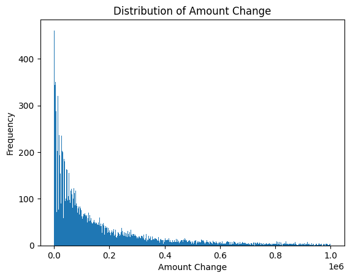

```python
import matplotlib.pyplot as plt
amount_change_filtered = amount_change[amount_change < 1e6]
plt.hist(amount_change_filtered.dropna(), bins=500)
plt.xlabel('Amount Change')
plt.ylabel('Frequency')
plt.title('Distribution of Amount Change')
plt.show()
```

```python
# 查找amount_change列中负数的位置
negative_values_mask = df['amount_change'] < 0

# 检查是否有任何负数
has_negative_values = negative_values_mask.any()

print("Has negative values in 'amount_change' column:", has_negative_values)

if has_negative_values:
    # 显示包含负数的行
    negative_rows = df[negative_values_mask]
    print("\nNegative value rows:")
    print(negative_rows)
```

```
Has negative values in 'amount_change' column: False
```

```python
# 计算金额变化和成交量变化之间的相关性
correlation = df['amount_change'].corr(df['volume_change'])

print("Correlation between amount change and volume change: {:.5f}".format(correlation))
```

```
Correlation between amount change and volume change: 0.99938
```

可以看到成交金额和成交量高度相关。

# 问题三

理想情況下，tick行情会 了s 推送一次，但实际中一些因素的影响，导致收到的行情是 非均匀的甚至 tick 缺失，请设计合适的清洗方式，使得新数据以 09:30:00 起始、14:56:57 结束，tick 频率3s一次，作为标准tick 数据(每日行情 4741 行）

```python
import pandas as pd
import datetime
from datetime import time
from datetime import datetime

date0 = datetime(2023, 4, 28).date()  # 第一天的日期

file_path0 = "/Users/churchillfelix/Desktop/data/0.csv"

df0 = pd.read_csv(file_path0)

import pandas as pd
import datetime
df0['date'] = date0

# 转换时间戳为datetime.time对象
def convert_to_time(timestamp):
    temp = int(timestamp) // 1000
    hh = temp // 10000
    temp = temp - hh * 10000
    mm = temp // 100
    ss = temp - mm * 100
    return time(hh, mm, ss)
df0['time'] = df0['timestamp'].apply(lambda x: convert_to_time(x))


# 为每个数据点创建一个包含日期和时间信息的datetime对象
df0['datetime'] = df0.apply(lambda x: datetime.datetime.combine(x['date'], x['time']), axis=1)

# 将新的datetime列设置为索引并按时间排序
df0.set_index('datetime', inplace=True)
df0.sort_index(inplace=True)

# 生成3秒间隔的时间范围
start_time1 = df0.index.min()
end_time2 = df0.index.max()

from datetime import datetime
date_string1 = "2023-04-28 11:30:00"
date_format1 = "%Y-%m-%d %H:%M:%S"

date_string2 = "2023-04-28 13:00:00"
date_format2 = "%Y-%m-%d %H:%M:%S"

end_time1 = datetime.strptime(date_string1, date_format1)
start_time2 = datetime.strptime(date_string2, date_format2)


time_range1 = pd.date_range(start=start_time1, end=end_time1, freq='3S')
time_range2 = pd.date_range(start=start_time2, end=end_time2, freq='3S')
time_range = time_range1.append(time_range2)

# 重新采样数据并插值
resampled_data = df0.reindex(time_range)
resampled_data.interpolate(method='linear', inplace=True)
resampled_data.drop('timestamp',axis=1,inplace=True)
resampled_data.reset_index(inplace=True)

# 将结果保存到CSV文件
resampled_data.to_csv('/Users/churchillfelix/Desktop/data/resampled_data_0.csv', index=False)
```

以上，0.csv被清洗完毕。

```python
import pandas as pd
import datetime
from datetime import time
from datetime import datetime

date0 = datetime(2023, 4, 29).date()  # 第一天的日期

file_path0 = "/Users/churchillfelix/Desktop/data/1.csv"

df1 = pd.read_csv(file_path0)

import pandas as pd
import datetime
df1['date'] = date0

# 转换时间戳为datetime.time对象
def convert_to_time(timestamp):
    temp = int(timestamp) // 1000
    hh = temp // 10000
    temp = temp - hh * 10000
    mm = temp // 100
    ss = temp - mm * 100
    return time(hh, mm, ss)
df1['time'] = df1['timestamp'].apply(lambda x: convert_to_time(x))


# 为每个数据点创建一个包含日期和时间信息的datetime对象
df1['datetime'] = df1.apply(lambda x: datetime.datetime.combine(x['date'], x['time']), axis=1)

# 将新的datetime列设置为索引并按时间排序
df1.set_index('datetime', inplace=True)
df1.sort_index(inplace=True)


# 生成3秒间隔的时间范围
start_time1 = df1.index.min()
end_time2 = df1.index.max()

from datetime import datetime
date_string1 = "2023-04-29 11:30:00"
date_format1 = "%Y-%m-%d %H:%M:%S"

date_string2 = "2023-04-29 13:00:00"
date_format2 = "%Y-%m-%d %H:%M:%S"

end_time1 = datetime.strptime(date_string1, date_format1)
start_time2 = datetime.strptime(date_string2, date_format2)

time_range1 = pd.date_range(start=start_time1, end=end_time1, freq='3S')
time_range2 = pd.date_range(start=start_time2, end=end_time2, freq='3S')
time_range = time_range1.append(time_range2)

# 重新采样数据并插值
resampled_data = df1.reindex(time_range)
resampled_data.interpolate(method='linear', inplace=True)
resampled_data.drop('timestamp',axis=1,inplace=True)
resampled_data.reset_index(inplace=True)

# 将结果保存到CSV文件
resampled_data.to_csv('/Users/churchillfelix/Desktop/data/resampled_data_1.csv', index=False)
```

以上，1.csv被清洗完毕。

```python
import pandas as pd
import datetime
from datetime import time
from datetime import datetime

date0 = datetime(2023, 4, 30).date()  # 第一天的日期

file_path0 = "/Users/churchillfelix/Desktop/data/2.csv"

df2 = pd.read_csv(file_path0)

import pandas as pd
import datetime
df2['date'] = date0

# 转换时间戳为datetime.time对象
def convert_to_time(timestamp):
    temp = int(timestamp) // 1000
    hh = temp // 10000
    temp = temp - hh * 10000
    mm = temp // 100
    ss = temp - mm * 100
    return time(hh, mm, ss)
df2['time'] = df2['timestamp'].apply(lambda x: convert_to_time(x))


# 为每个数据点创建一个包含日期和时间信息的datetime对象
df2['datetime'] = df2.apply(lambda x: datetime.datetime.combine(x['date'], x['time']), axis=1)

# 将新的datetime列设置为索引并按时间排序
df2.set_index('datetime', inplace=True)
df2.sort_index(inplace=True)


# 生成3秒间隔的时间范围
start_time1 = df2.index.min()
end_time2 = df2.index.max()

from datetime import datetime
date_string1 = "2023-04-30 11:30:00"
date_format1 = "%Y-%m-%d %H:%M:%S"

date_string2 = "2023-04-30 13:00:00"
date_format2 = "%Y-%m-%d %H:%M:%S"

end_time1 = datetime.strptime(date_string1, date_format1)
start_time2 = datetime.strptime(date_string2, date_format2)

time_range1 = pd.date_range(start=start_time1, end=end_time1, freq='3S')
time_range2 = pd.date_range(start=start_time2, end=end_time2, freq='3S')
time_range = time_range1.append(time_range2)

# 重新采样数据并插值
resampled_data = df2.reindex(time_range)
resampled_data.interpolate(method='linear', inplace=True)
resampled_data.drop('timestamp',axis=1,inplace=True)
resampled_data.reset_index(inplace=True)

# 将结果保存到CSV文件
resampled_data.to_csv('/Users/churchillfelix/Desktop/data/resampled_data_2.csv', index=False)
```

```python
以上，2.csv被清洗完毕。
```

# 问题四

定义：盘口中间价格mp=0.5* (apl + bp1)、盘口价差比例 spdr = (ap1-bp1) / mp，观察 spdr 数据分布变化，总结有意义的现象，如某些tick spdt 突然变大的原因

```python
redf0 = pd.read_csv('/Users/churchillfelix/Desktop/data/resampled_data_0.csv')
```

```python
redf1 = pd.read_csv('/Users/churchillfelix/Desktop/data/resampled_data_1.csv')
```

```python
redf2 = pd.read_csv('/Users/churchillfelix/Desktop/data/resampled_data_2.csv')
```

```python
def add2(x):
    x['mp'] = 0.5*(x['ap1']+x['bp1'])
    x['spdr'] = (x['ap1']-x['bp1'])/x['mp']
    return x
redf0 = add2(redf0)
redf1 = add2(redf1)
redf2 = add2(redf2)
```

```python
spdr_stats0 = redf0['spdr'].describe()
print(spdr_stats0)
```

```
count    4741.000000
mean        0.000608
std         0.000484
min         0.000395
25%         0.000408
50%         0.000411
75%         0.000809
max         0.008449
Name: spdr, dtype: float64
```

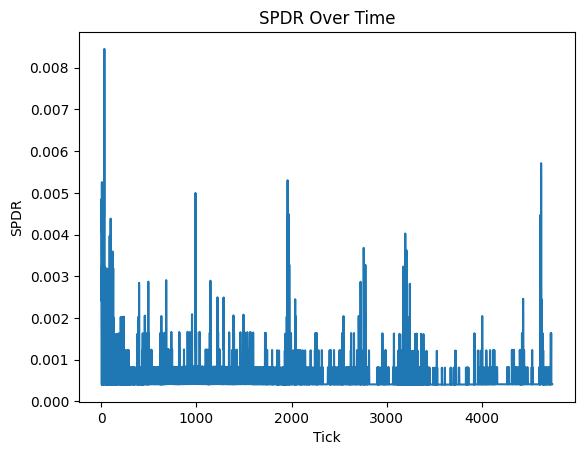

```python
import matplotlib.pyplot as plt

plt.plot(redf0['spdr'])
plt.xlabel('Tick')
plt.ylabel('SPDR')
plt.title('SPDR Over Time')
plt.show()
```

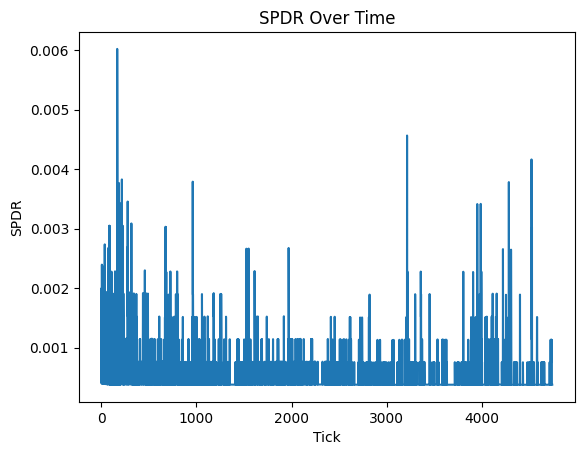

```python
plt.plot(redf1['spdr'])
plt.xlabel('Tick')
plt.ylabel('SPDR')
plt.title('SPDR Over Time')
plt.show()
```

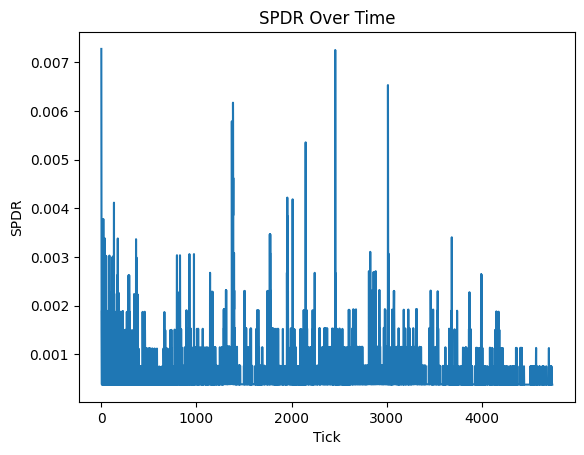

```python
plt.plot(redf2['spdr'])
plt.xlabel('Tick')
plt.ylabel('SPDR')
plt.title('SPDR Over Time')
plt.show()
```

1. 刚开盘时，spdr持续扩大，这可能是因为市场参与者对未来价格趋势的预期存在较大不确定性，在这种情况下，交易者可能会变得更加谨慎，以防止在不利的价格水平上进行交易。
2. 开盘一段时间后，市场流动性逐渐提高，买卖双方对价格趋势的共识逐渐增强。在这种情况下，交易者可能会更愿意进行交易，因为他们认为市场价格具有更好的稳定性，spdr逐渐缩小。
3. 一段时间内，spdr在某个范围内波动：这表示市场在一个相对稳定的价格区间内进行交易，买卖双方对价格的预期相对一致。这种情况可能出现在市场信息相对均衡的情况下。
4. 注意到在早上开盘一小时后，中午暂停前，下午开盘一小时后，闭盘前，spdr突然变大，这可能意味着市场中的买卖双方出现了分歧，或者某方面的信息导致市场参与者对价格产生不同的预期。

# 问题五

### 选择你认为最优的方案，对于任意时刻t，定义过去20个tick的波动性，需考虑震荡上涨/下跌和快速上涨/下跌的区别，并分析该定义的优缺点。

我们可以使用简单移动平均（Simple Moving Average，SMA）来计算价格变化的平均绝对值，并结合上涨/下跌的比例来分析。具体步骤如下：

1. 计算每个tick的价格变化：`price_change = (current_mp - previous_mp)`
2. 对价格变化进行SMA处理：`SMA_20 = average(price_change, window=20)`
3. 计算每个tick的价格变化的绝对值：`abs_price_change = abs(price_change)`
4. 对绝对价格变化进行SMA处理：`SMA_20_abs = average(abs_price_change, window=20)`
5. 计算波动性指标：`volatility = SMA_20_abs`
6. 计算上涨/下跌比例：`up_down_ratio = SMA_20 / SMA_20_abs`

**优点：**

- 使用SMA可以平滑价格变化，减少噪声对波动性的影响。
- 计算简单，易于理解和实现。
- 结合上涨/下跌比例可以区分震荡上涨/下跌和快速上涨/下跌的情况。当`up_down_ratio`接近1或-1时，表示快速上涨/下跌；当`up_down_ratio`接近0时，表示震荡。

**缺点：**

- 该定义较为简化，可能无法捕捉到更复杂的价格变化模式。
- 使用固定的20个tick窗口可能无法适应不同的市场环境，需要根据实际情况调整参数。
- 该定义仅考虑了过去的价格变化，未考虑其他可能影响波动性的因素，如成交量、市场情绪等。

```python
def p5(data):
    # 计算每个tick的价格变化
    data['price_change'] = data['mp'].diff()

    # 对价格变化进行SMA处理
    window = 20
    data['SMA_20'] = data['price_change'].rolling(window=window).mean()

    # 计算每个tick的价格变化的绝对值
    data['abs_price_change'] = data['price_change'].abs()

    # 对绝对价格变化进行SMA处理
    data['SMA_20_abs'] = data['abs_price_change'].rolling(window=window).mean()

    # 计算波动性指标
    data['volatility'] = data['SMA_20_abs']

    # 计算上涨/下跌比例
    data['up_down_ratio'] = data['SMA_20'] / data['SMA_20_abs']
    return data
resultofp50 = p5(redf0)
resultofp51 = p5(redf1)
resultofp52 = p5(redf2)
```

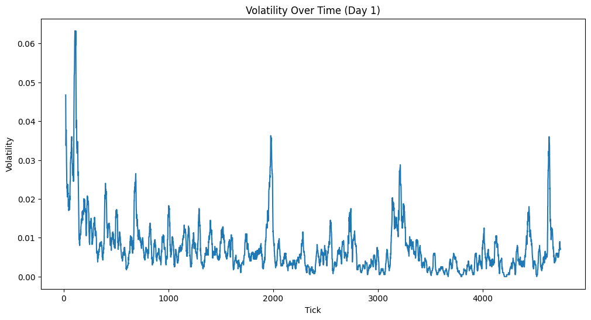

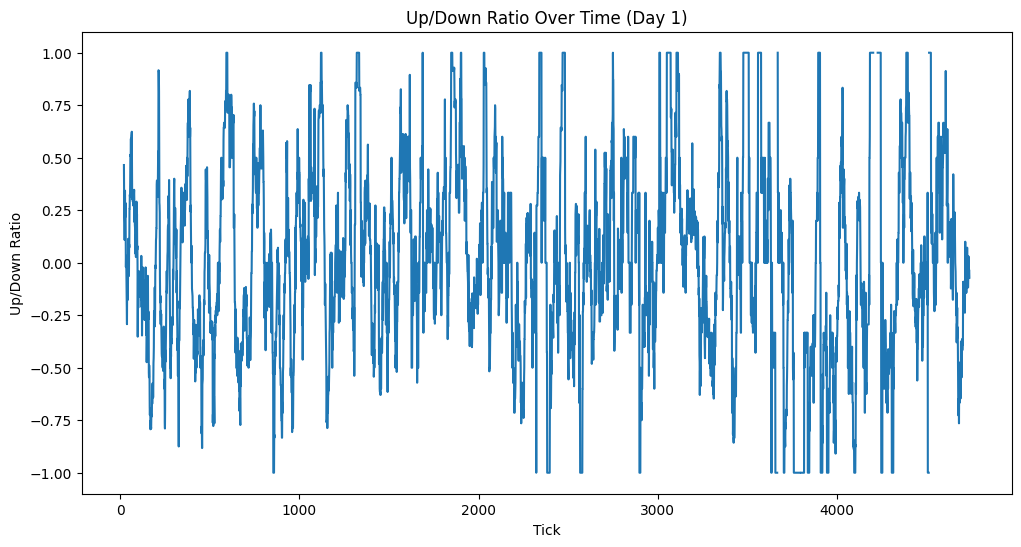

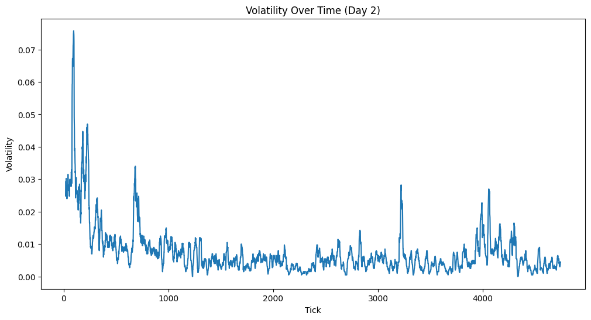

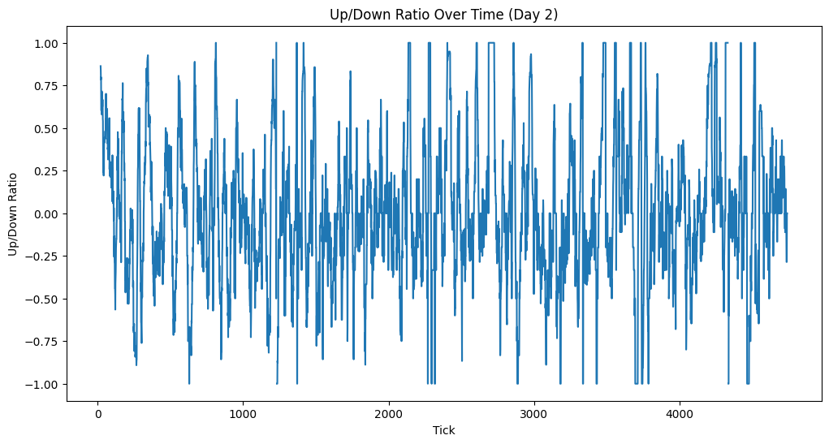

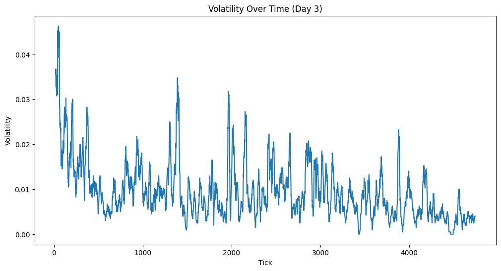

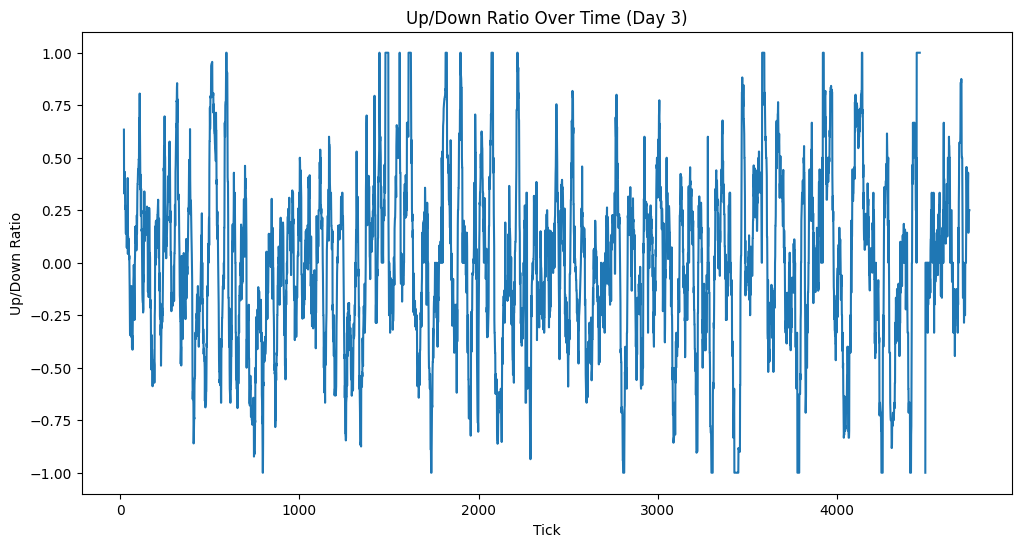

```python
import matplotlib.pyplot as plt

def huatu5(data, dataset_label):
    # 绘制波动性随时间变化的趋势
    plt.figure(figsize=(12, 6))
    plt.plot(data['volatility'])
    plt.xlabel('Tick')
    plt.ylabel('Volatility')
    plt.title(f'Volatility Over Time ({dataset_label})')
    plt.show()

    # 绘制上涨/下跌比例随时间变化的趋势
    plt.figure(figsize=(12, 6))
    plt.plot(data['up_down_ratio'])
    plt.xlabel('Tick')
    plt.ylabel('Up/Down Ratio')
    plt.title(f'Up/Down Ratio Over Time ({dataset_label})')
    plt.show()
huatu5(resultofp50, 'Day 1')
huatu5(resultofp51, 'Day 2')
huatu5(resultofp52, 'Day 3')
```

# 问题六

### 在任意时间t，定义：订单薄的买卖不均衡 imbalance = (bv1 - av1)/(bv1 + av1)，买方力量强时，因子值大；卖方力量强时，因子值小。我们认为：imbalance 与未来一段时间的价格走势相关。但该 inbalance 的定义过于简单，选择你认为更优的方案，重新定义imbalance，解释其背后的逻辑，并通过统计检验分析 imbalance 与未来价格走势的关系

原始的定义只考虑了最优价格层次上的挂单量差异，而实际上不同价格层次的挂单价格和挂单量对未来价格走势的影响不同，因此我们可以采用加权订单簿不均衡来更好反映市场上买卖双方的力量对比，它的计算方法是：

1. 通过将订单量和价格相乘，计算出每个价格层次上的买卖力量；
2. 加权不均衡指标的分子部分是买方力量减去卖方力量，分母部分是买方力量加上卖方力量。

通过使用加权订单簿不均衡，我们可以更准确地衡量市场上买卖双方的力量对比，并根据这一指标预测未来价格走势。这是因为加权不均衡综合考虑了多个价格层次上的挂单信息，而非仅关注买一和卖一的挂单量。

```python
def calculate_weighted_imbalance(data, n_levels=10):
    bid_volumes = [data[f"bv{i+1}"] for i in range(n_levels)]
    bid_prices = [data[f"bp{i+1}"] for i in range(n_levels)]
    ask_volumes = [data[f"av{i+1}"] for i in range(n_levels)]
    ask_prices = [data[f"ap{i+1}"] for i in range(n_levels)]

    bids = sum([volume * price for volume, price in zip(bid_volumes, bid_prices)])
    asks = sum([volume * price for volume, price in zip(ask_volumes, ask_prices)])

    weighted_imbalance = (bids - asks) / (bids + asks)
    return weighted_imbalance

# 计算加权订单薄不均衡，并将结果添加到数据框中
resultofp50["weighted_imbalance"] = calculate_weighted_imbalance(resultofp50)
resultofp51["weighted_imbalance"] = calculate_weighted_imbalance(resultofp51)
resultofp52["weighted_imbalance"] = calculate_weighted_imbalance(resultofp52)
```

```python
from scipy.stats import pearsonr
def test(data, dataset_label):
    look_forward = 100
    data['future_price_change'] = data['mp'].shift(-look_forward) - data['mp']
    # 去除缺失值，因为计算相关系数和p值时不能有缺失值
    data_cleaned = data.dropna(subset=['weighted_imbalance', 'future_price_change'])
    # 计算相关系数和p值
    correlation, p_value = pearsonr(data_cleaned['weighted_imbalance'], data_cleaned['future_price_change'])

    print(f"Correlation between weighted imbalance and future price change in {dataset_label}: {correlation}")
    print(f"P-value for {dataset_label}: {p_value}")
test(resultofp50,'day1')
test(resultofp51,'day2')
test(resultofp52,'day3')
```

```
Correlation between weighted imbalance and future price change in day1: 0.06309099320214655
P-value for day1: 1.6988013053727618e-05
Correlation between weighted imbalance and future price change in day2: 0.26385316028214706
P-value for day2: 9.02514197553507e-75
Correlation between weighted imbalance and future price change in day3: 0.060788748542030535
P-value for day3: 3.4138396777877404e-05
```

根据检验结果，有极大的把握认为新定义的加权不平衡与未来价格存在正相关关系，但关系比较微弱。

# 问题七

定义：相邻tick间的成交量=主动买量＋主动卖量

- 主动买 act buy： 价格 高于或等于 卖方一档价格的买单
- 主动卖 act sel： 价格 低于或等于 买方一档价格的卖单

请选择你认为最优的方案，估计相邻 tick 间的主动买卖量，并列出可能存在的问题

由于数据中没有具体的交易数据（包括每笔交易的价格、成交量和时间戳），以下采用一种估计的办法来算主动买卖量，假设每个tick之间的成交量变化主要是由主动买卖引起的：

```python
def buysell(data):
    #首先，计算每个tick之间的成交量变化
    data['volume_change'] = data['ttvol'].diff()
    #接下来，我们需要找出每个tick之间价格的变化。使用last（最新成交价）计算价格变化：
    data['price_change'] = data['last'].diff()
    #现在，我们可以根据价格变化和卖一/买一挂单价来估计主动买卖量。假设：如果价格上涨（price_change > 0），我们认为主动买量占据主导地位。如果价格下跌（price_change < 0），我们认为主动卖量占据主导地位。
    data['active_buy_volume'] = data.apply(lambda x: x['volume_change'] if x['price_change'] > 0 else 0, axis=1)
    data['active_sell_volume'] = data.apply(lambda x: x['volume_change'] if x['price_change'] < 0 else 0, axis=1)
    return data
resultofp50 = buysell(resultofp50)
resultofp51 = buysell(resultofp51)
resultofp52 = buysell(resultofp52)
```

```
                 index  preclose  open   high    low   last  tradecount
0  2023-04-28 09:30:00     23.85  24.8  24.80  24.50  24.60       692.0  \
1  2023-04-28 09:30:03     23.85  24.8  24.80  24.14  24.78      1292.0
2  2023-04-28 09:30:06     23.85  24.8  24.88  24.14  24.82      1661.0
3  2023-04-28 09:30:09     23.85  24.8  24.88  24.14  24.80      1925.0
4  2023-04-28 09:30:12     23.85  24.8  24.88  24.14  24.88      2085.0

       ttvol         ttval    ap1  ...  SMA_20  abs_price_change  SMA_20_abs
0  2469400.0  6.121664e+07  24.60  ...     NaN               NaN         NaN  \
1  3684778.0  9.116007e+07  24.80  ...     NaN              0.19         NaN
2  4314378.0  1.067693e+08  24.88  ...     NaN              0.11         NaN
3  4647678.0  1.150363e+08  24.88  ...     NaN              0.01         NaN
4  4914778.0  1.216666e+08  24.87  ...     NaN              0.00         NaN

   volatility  up_down_ratio  weighted_imbalance  future_price_change
0         NaN            NaN           -0.813276                0.555  \
1         NaN            NaN           -0.712525                0.460
2         NaN            NaN           -0.574827                0.330
3         NaN            NaN           -0.318685                0.310
4         NaN            NaN           -0.290819                0.365

   volume_change  active_buy_volume  active_sell_volume
0            NaN                0.0                 0.0
1      1215378.0          1215378.0                 0.0
2       629600.0           629600.0                 0.0
3       333300.0                0.0            333300.0
4       267100.0           267100.0                 0.0

[5 rows x 64 columns]
```

这种近似方法可能会引入一定程度的偏差，并且在某些情况下可能无法准确反映实际的主动买卖量。

# 问题八

根据主动买卖量，设计成交类型因子 trade_fc，统计检验分析 trade_fc 与未来价格走势的关系

可以定义：

- trade_fc = 主动买量 / (主动买量 + 主动卖量)

来衡量买力相对于卖力的强度。 在之前的计算方法中，我们只能区分是否发生了主动买卖，而无法得到实际的主动买卖量。在这种情况下，trade_fc 的取值只能是0或1，这会限制我们在分析中获得更多关于主动买卖力量差异的信息。 一种可能的解决方法是计算相邻tick之间的成交量变化，然后将这个变化量与上一个tick的主动买卖方向结合起来。具体操作如下：

```python
#假设，如果上一个tick的最后成交价大于等于上一个tick的卖一价，则认为上一个tick是主动买方。否则，认为是主动卖方。
import numpy as np
import pandas as pd
def compute_trade_fc(data):

    # 1. 计算上一个tick的主动买卖方向
    data['trade_direction'] = np.where(data['last'].shift(1) >= data['ap1'].shift(1), 1, 0)

    # 2. 计算每个tick的近似主动买卖量
    data['approx_active_trade_volume'] = data['volume_change'] * data['trade_direction']

    # 3. 使用这个近似的主动买卖量来计算 trade_fc
    data['trade_fc'] = data['approx_active_trade_volume'] / data['ttvol']

    return data
resultofp50 = compute_trade_fc(resultofp50)
resultofp51 = compute_trade_fc(resultofp51)
resultofp52 = compute_trade_fc(resultofp52)
```

```
                 index  preclose  open   high    low   last  tradecount
0  2023-04-28 09:30:00     23.85  24.8  24.80  24.50  24.60       692.0  \
1  2023-04-28 09:30:03     23.85  24.8  24.80  24.14  24.78      1292.0
2  2023-04-28 09:30:06     23.85  24.8  24.88  24.14  24.82      1661.0
3  2023-04-28 09:30:09     23.85  24.8  24.88  24.14  24.80      1925.0
4  2023-04-28 09:30:12     23.85  24.8  24.88  24.14  24.88      2085.0
5  2023-04-28 09:30:15     23.85  24.8  24.88  24.14  24.80      2237.0
6  2023-04-28 09:30:18     23.85  24.8  24.88  24.14  24.80      2347.0
7  2023-04-28 09:30:21     23.85  24.8  24.88  24.14  24.87      2447.0
8  2023-04-28 09:30:24     23.85  24.8  24.88  24.14  24.85      2525.0
9  2023-04-28 09:30:27     23.85  24.8  24.88  24.14  24.80      2640.0

       ttvol         ttval    ap1  ...  volatility  up_down_ratio
0  2469400.0  6.121664e+07  24.60  ...         NaN            NaN  \
1  3684778.0  9.116007e+07  24.80  ...         NaN            NaN
```

[output cut: 34 more lines]

这个方法仍然是一个近似，但它至少可以提供一个更细粒度的度量。

```python
import scipy.stats
def analyze_trade_fc_future_price_relation(data, look_forward, label):
    # 计算未来价格变化
    data['future_price_change'] = data['last'].shift(-look_forward) - data['last']

    # 去除缺失值（由于.shift(-look_forward)引入）
    data = data.dropna()

    # 计算皮尔逊相关系数
    correlation, p_value = scipy.stats.pearsonr(data['trade_fc'], data['future_price_change'])
    print(f"correlation and P-value in {label} is {correlation} and {p_value}.")
look_forward = 10
analyze_trade_fc_future_price_relation(resultofp50, look_forward,'day1')
analyze_trade_fc_future_price_relation(resultofp51, look_forward,'day2')
analyze_trade_fc_future_price_relation(resultofp52, look_forward,'day3')
```

```
correlation and P-value in day1 is -0.00881423850973244 and 0.5476906932494664.
correlation and P-value in day2 is 0.11934319036803015 and 2.3312095376945825e-16.
correlation and P-value in day3 is 0.03248173626725764 and 0.02643854074490756.
```

### 问题九

定义撤单：相邻tick 间，订单薄 orderbook 上每一档撤消的挂单量。根据 10挡 orderbook的挂单量以及估算的主动买卖量，估计相邻tick 间每一档价格上对应的撤单量

- 我们将之前估算的总主动买卖量按比例分配给每一档；
- 再计算每一档价格上的挂单量变化；
- 然后从挂单量变化中减去估计的主动买卖量，以得到每一档价格上的撤单量。

```python
import pandas as pd

def calculate_canceled_volumes(data):
    # 计算相邻 tick 间的挂单量变化
    bid_columns = [f"bv{i+1}" for i in range(10)]
    ask_columns = [f"av{i+1}" for i in range(10)]

    bid_vol_changes = data[bid_columns].diff().dropna()
    ask_vol_changes = data[ask_columns].diff().dropna()

    # 估计每个价格档位的主动买卖量
    bid_ratios = data[bid_columns].div(data[bid_columns].sum(axis=1), axis=0)
    ask_ratios = data[ask_columns].div(data[ask_columns].sum(axis=1), axis=0)
    estimated_active_buy_vol_per_level = bid_ratios.mul(data['active_buy_volume'], axis=0)
    estimated_active_sell_vol_per_level = ask_ratios.mul(data['active_sell_volume'], axis=0)

    # 计算撤单量
    canceled_bid_volumes = bid_vol_changes - estimated_active_buy_vol_per_level
    canceled_ask_volumes = ask_vol_changes - estimated_active_sell_vol_per_level
    # 处理负数和NaN值
    canceled_bid_volumes = canceled_bid_volumes.clip(lower=0).fillna(0)
    canceled_ask_volumes = canceled_ask_volumes.clip(lower=0).fillna(0)

    # 添加撤单量到原始数据集
    data_with_canceled_volumes = data.copy()
    for i in range(1, len(bid_columns) + 1):
        data_with_canceled_volumes[f"cbv{i}"] = canceled_bid_volumes[f"bv{i}"]
        data_with_canceled_volumes[f"cav{i}"] = canceled_ask_volumes[f"av{i}"]

    return data_with_canceled_volumes


data0_with_canceled_volumes = calculate_canceled_volumes(resultofp50)
data1_with_canceled_volumes = calculate_canceled_volumes(resultofp51)
data2_with_canceled_volumes = calculate_canceled_volumes(resultofp52)
```

# 问题十

结合对该股票的其他观察，统计和猜测，有什么可以盈利的策略？写出策略的思路、可 以盈利的原因以及什么时候可能不盈利（提示：不计手续费；可以低买高卖/高卖低买）

策略思路：

1. 设定一个加权订单薄不均衡阈值（例如：0.1），当加权订单薄不均衡大于该阈值时，表示买方力量较强，可以考虑买入。
2. 设定一个主动买卖量阈值（例如：5000），当主动买量大于主动卖量且差值大于该阈值时，表示买方意愿较强，可以考虑买入。
3. 当加权订单薄不均衡小于负的阈值（例如：-0.1）时，表示卖方力量较强，可以考虑卖出。
4. 当主动卖量大于主动买量且差值大于阈值时，表示卖方意愿较强，可以考虑卖出。
5. 对于每个交易信号，可以设定止损和止盈条件，以控制交易风险。
6. 对策略参数进行优化：您可以尝试不同的加权订单薄不均衡阈值、主动买卖量阈值、止损和止盈条件等参数，以找到最佳参数组合。
7. 添加更多因子：您可以考虑引入其他因子，如技术指标、基本面数据或市场情绪等，以提高策略的预测准确性。

可以盈利的原因：

1. 加权订单薄不均衡可以反映市场上买卖力量的相对强弱，当买方力量强时，价格可能上涨；当卖方力量强时，价格可能下跌。
2. 主动买卖量可以反映市场参与者的主动交易意愿，当主动买量较大时，价格可能上涨；当主动卖量较大时，价格可能下跌。

什么时候可能不盈利：

1. 当市场波动较大，价格变动剧烈时，此策略可能无法准确预测价格走势。
2. 当市场信息不完整或者数据质量较差时，策略的预测准确性可能会降低。
3. 当市场受到外部因素（如政策、突发事件等）的影响时，策略的表现可能受到影响。